# Week7

Deirdre Toher and Paul Hewson, with Ciaran’s :D Emoji marked comments

23/03/2021

# Recap from last week: generic rule of thumb for a 95% Confidence Interval

$$\hat{\theta} \pm 2 se(\theta)$$

This rule of thumb is worth memorising. It can be really useful, whether working with written reports or when wanting a quick check on some data analysis.

## Computing CIs: an example with fake data

Repeating the example from the presentation

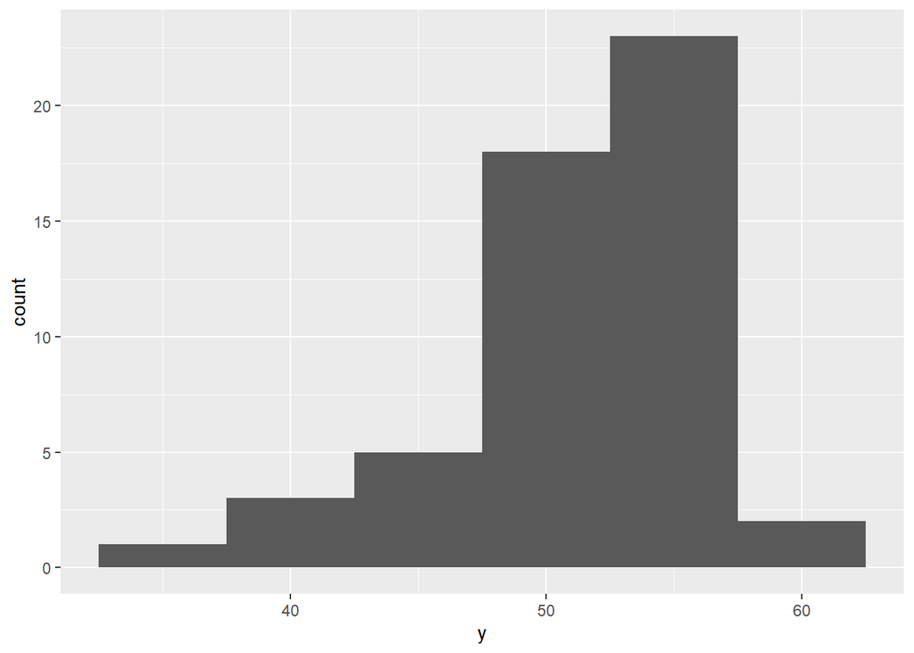

```r
set.seed(6436)
N<-52 # the size of the sample we will create :nerd:
y <- rnorm(N, 50, 5) # Uses the normal distribution with mean = 50, and standard deviation = 5
fake <- data.frame(y=y)
fake %>%
  ggplot(aes(y)) +
  geom_histogram(binwidth = 5)
```

To rehearse the key idea, we will calculate a 95 percent confidence interval :D *they’re talking about seeing if our tests will still find the mean is 50 or not!*

$$\bar{x} \pm 2 \times \mbox{standard error of the mean}$$

where

$$\mbox{standard error of the mean} = \frac{sd}{\sqrt{n}}$$

```r
model_fake <- lm(y ~ 1, data = fake)
CI <- confint(model_fake, level=0.95)
CI
```

```
##                2.5 %  97.5 %
## (Intercept) 50.00134 52.6473
```

This implies that the mean is around 51.3

### Exercise 1a: Complete the code to calculate the confidence limits

Create a bootstrap estimate of the CI for the mean of the fake data. Start by doing this for 40 bootstrap samples, then increase the number of samples appropriately.

:nerd: I forgot to change up this 40 in the lesson, so have a look at the following histograms of x40 bootstrap samples, then x400 bootstraps, then a crazy big x40,000 samples. Look at the axes, have they changed, or has the widow just moved a bit? How else does this change? Try fiddling with the sample size & see what happens.

```r
set.seed(09971654)
sample_size <-52
boot_var_generator <- function(Nb){
Bootvar<-rep(NA,Nb) # creat an empty sample
for(i in seq_len(Nb)){
  temp.boot<-fake$y[sample(seq_len(N),sample_size,replace=TRUE)]
   Bootvar[i] <- var(temp.boot)
# this takes a sub-sample from fake$y, gets the variance of it, then repeats for Nb tries
}
Bootvar
}
```

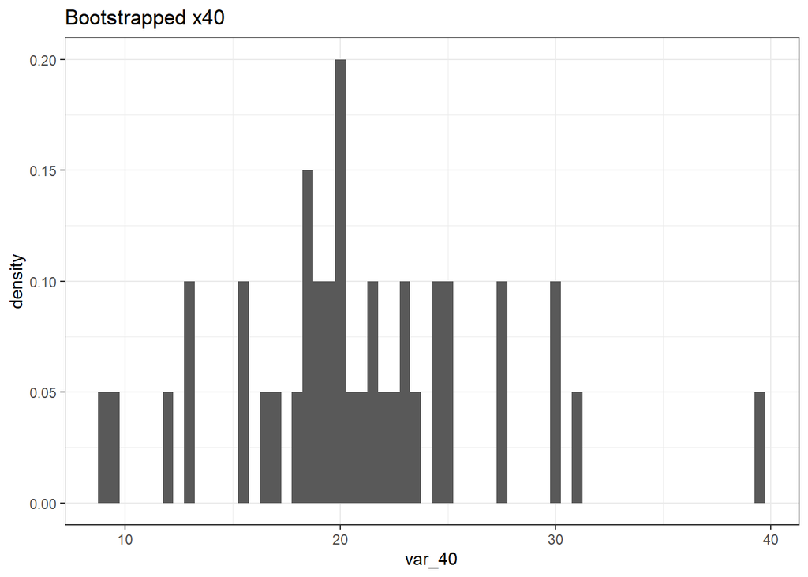

```r
bs_40 <- boot_var_generator(40)
Bootstrap <- data.frame(var_40=bs_40)
ggplot(Bootstrap, aes(x=var_40)) +
geom_histogram(aes(y = ..density..),binwidth = .5)+
ggtitle("Bootstrapped x40")+
theme_bw()
```

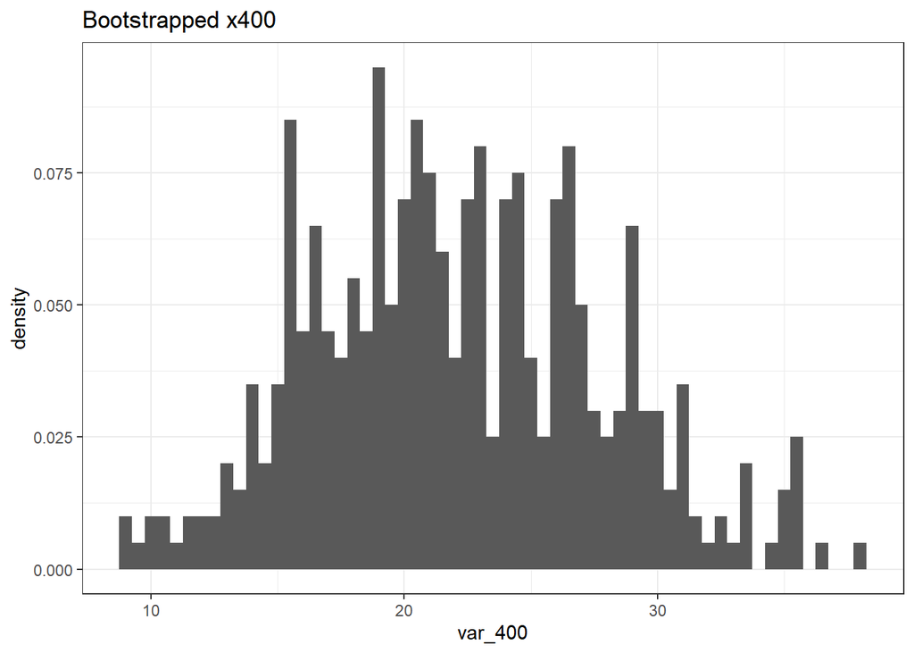

```r
bs_400 <- boot_var_generator(400)
Bootstrap <- data.frame(var_400=bs_400)
ggplot(Bootstrap, aes(x=var_400)) +
geom_histogram(aes(y = ..density..),binwidth = .5)+
ggtitle("Bootstrapped x400")+
theme_bw()
```

Here’s the code for the big one. The graphs above use 40 and 400 instead of 40,000.

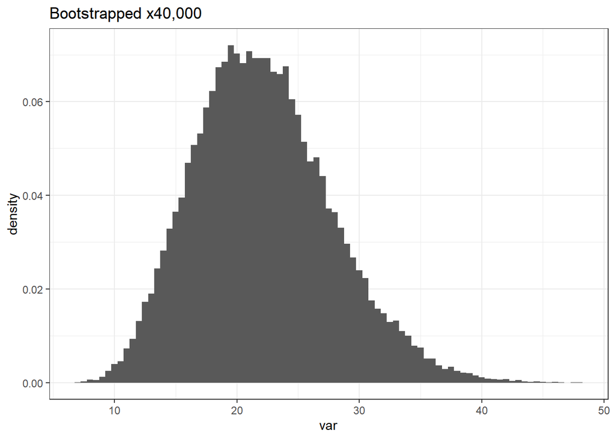

```r
Bootstrap <- data.frame(var=boot_var_generator(40000))
ggplot(Bootstrap, aes(x=var)) +
geom_histogram(aes(y = ..density..),binwidth = .5)+
ggtitle("Bootstrapped x40,000")+
theme_bw()
```

## Kickstarter Data

This is a large dataset. It may speed things up if you take a random subsample. We will start by selecting only the kickstarter projects with at least one backer!

```r
kickstarter<-kickstarter[kickstarter$backers>0,]
# this will overwrite the original dataset in R, but not in your original data file.
```

The following code takes a random sample of 10,000 rows from the data, and then deletes the large dataset. Feel free to reduce the sample size if your computer needs it.

```r
set.seed(7637) # for reproducability!
n_subsample <- 10000 # deliberately much smaller here.
index <- sample(seq_along(kickstarter$ID), n_subsample)
my_kickstarter <- kickstarter[index, ]
rm(kickstarter)
```

### Looking at the number of backers by state of project

As an example to get us started, here is a boxplot of the number of funders by the state of each project. You might like to experiment with adding and removing the `scale_y_log10()` instruction.

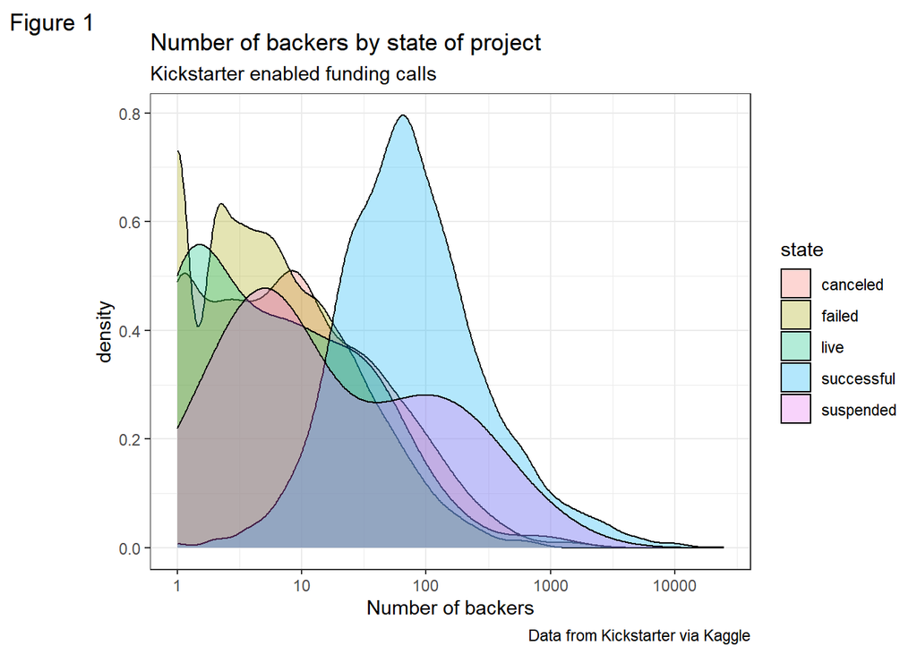

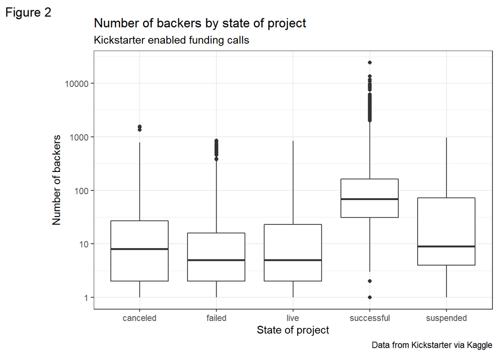

I would suggest this is challenging data to visualise well. But it could be worth getting to grips with this because the implication is that `succesful` projects tend to have more backers than `failed` projects.

### Construct some confidence intervals using the bootstrap approach

Create a set of bootstrap samples of your data and then use it to estimate confidence intervals for

1. Mean of usd_goal_real
2. Median of usd_goal_real
3. Variance of usd_goal_real
4. Mean number of backers by the state of the project.

```r
boot_kicks <- function(Nbootstrap, size=40){

MeanBts<-rep(NA,Nbootstrap)
MedianBts<-rep(NA,Nbootstrap)
VarBts<-rep(NA,Nbootstrap)

set.seed(007)
for(i in seq_len(Nbootstrap)){
  usevalues<-sample(seq_along(my_kickstarter$ID),size,replace=TRUE)
  sample<-my_kickstarter[usevalues,]
  MeanBts[i]<- mean(sample$usd_goal_real)
  MedianBts[i] <- median(sample$usd_goal_real)
  VarBts[i] <- var(sample$usd_goal_real)
}
Boot_goals <- cbind(data.frame(MeanBts), data.frame(MedianBts), data.frame(VarBts))
Boot_goals
}
```

Plot a histogram of the values of the bootstrap means

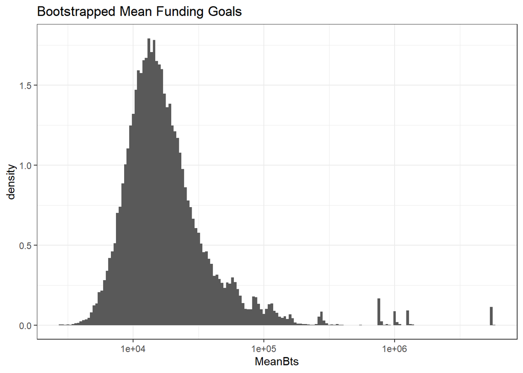

```r
Boot_goals = boot_kicks(50000, 20) #small samples, but lots of them
ggplot(Boot_goals, aes(x=MeanBts)) +
geom_histogram(aes(y = ..density..),binwidth = 0.02)+
scale_x_log10() +
ggtitle("Bootstrapped Mean Funding Goals")+
theme_bw()
```

What is the 95% confidence interval of the bootstrap means?

```r
(ciMeans<- quantile(Boot_goals$MeanBts,probs=c(.025,0.975))) # (uncomment out when ready to do the calculation)
```

```
##       2.5%      97.5%
##   6197.058 116829.672
```

You can you report this as “in line” rather within a code - 6197.058075, 1.1682967^{5}. This needs backticks and must start with “r” - r + space. How does this estimate compare to a traditional estimate of the confidence interval for the mean usd_goal_real?

What happens if you increase the number of bootstrap samples taken?

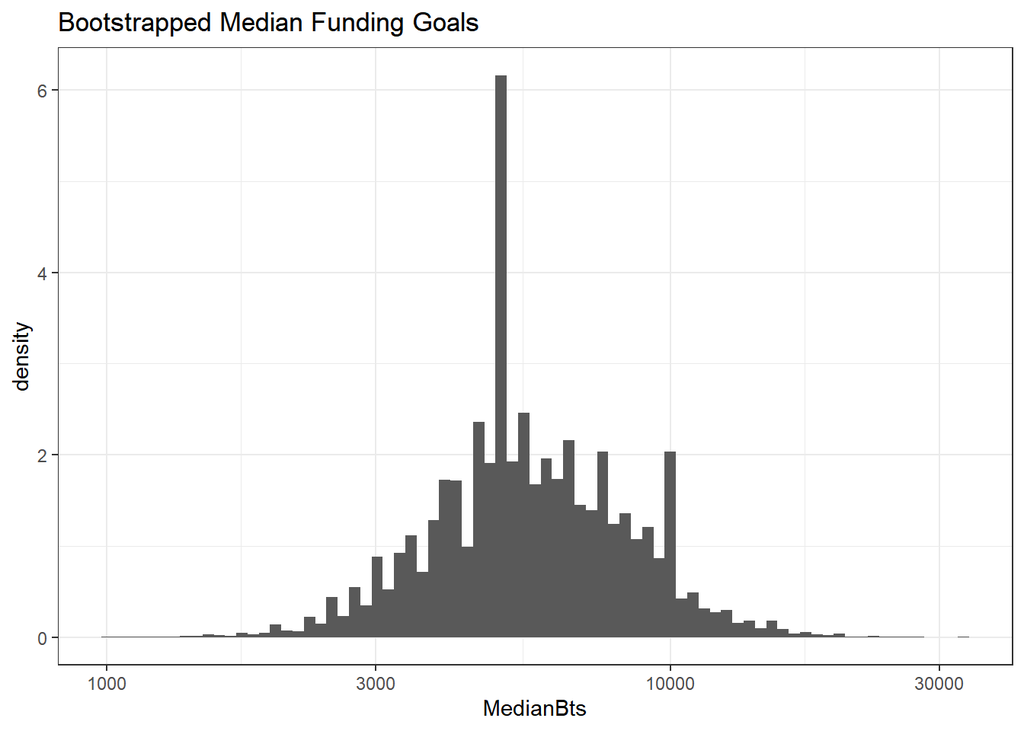

```r
ggplot(Boot_goals, aes(x=MedianBts)) +
geom_histogram(aes(y = ..density..),binwidth = 0.02)+
scale_x_log10() +
ggtitle("Bootstrapped Median Funding Goals")+
theme_bw()
```

What is the 95% confidence interval of the bootstrap medians? 2550, 1.225^{4}

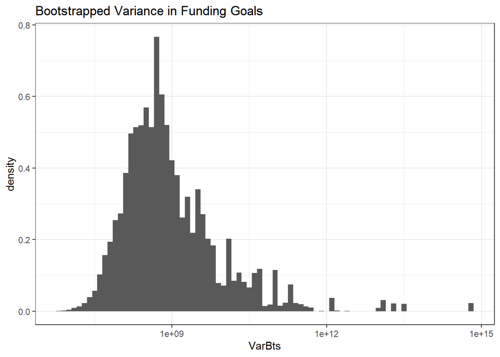

```r
ggplot(Boot_goals, aes(x=VarBts)) +
geom_histogram(aes(y = ..density..),binwidth = 0.1)+
scale_x_log10() +
ggtitle("Bootstrapped Variance in Funding Goals")+
theme_bw()
```

What is the 95% confidence interval of the bootstrap variances?

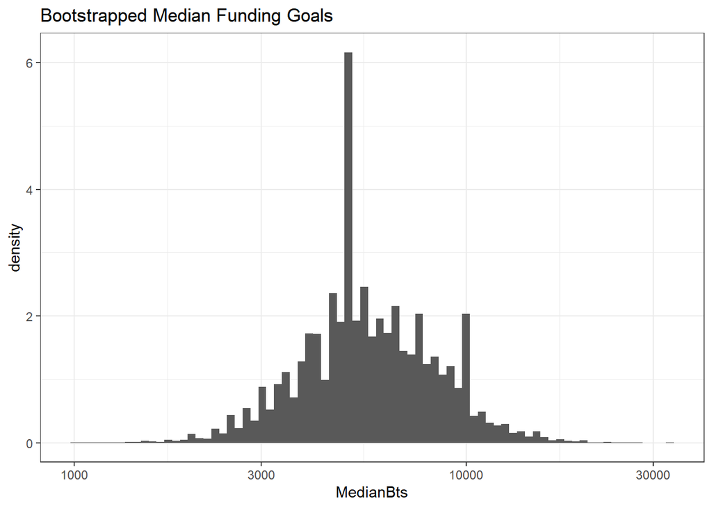

```r
Boot_goals = boot_kicks(50000,20)
ggplot(Boot_goals, aes(x=MedianBts)) +
geom_histogram(aes(y = ..density..),binwidth = 0.02)+
scale_x_log10() +
ggtitle("Bootstrapped Median Funding Goals")+
theme_bw()
```

What is the 95% confidence interval of the bootstrap mean number of backers?

# Exercise 3

Think about the more complex scenarios that you may want to create estimates / confidence intervals for.

For example: confidence intervals for the number of backers for successful projects versus the number of backers for failed projects.

Based on this dataset; what research questions would you like to answer that bootstrapping may be a suitable approach?